# checkpoint3

Carlos Interaminense

June 27, 2017

# Analisando dados de filmes…

Neste post, vamos analisar os dados de filmes com base na quantidade de homens e mulheres em cada filme, assim como suas idades e quantidade de palavras que falaram nos filmes. A seguir, os dados são carregados, vamos desconsiderar dados inválidos, ou seja, valores ‘NULL’ e/ou ‘NA’.

```r
#Carrega os arquivos
personagens_informacoes = read_csv("character_list5.csv")
filmes = read_csv("meta_data7.csv")

# Filtra os filmes, descartando os que têm gross = 'NA'
filmes = filter(filmes, gross != 'NA')

#Filtra os personagens, descartando os que têm idade NULL
personagens_informacoes = filter (personagens_informacoes, age != 'NULL') %>%
  mutate(age = as.numeric(age))
```

Com as dados carregados, precisamos observar se existem valores inconsistentes nos nossos dados. Por exemplo, as idades dos personagens devem variar de 0 até 130, sende este último valor um valor empírico, pois consideramos que não há pessoas com mais de 130 anos de idade. Para observarmos isso, o histograma abaixo mostra se existe pessoas com idade fora do intervalo citado anteriormente [0-130]:

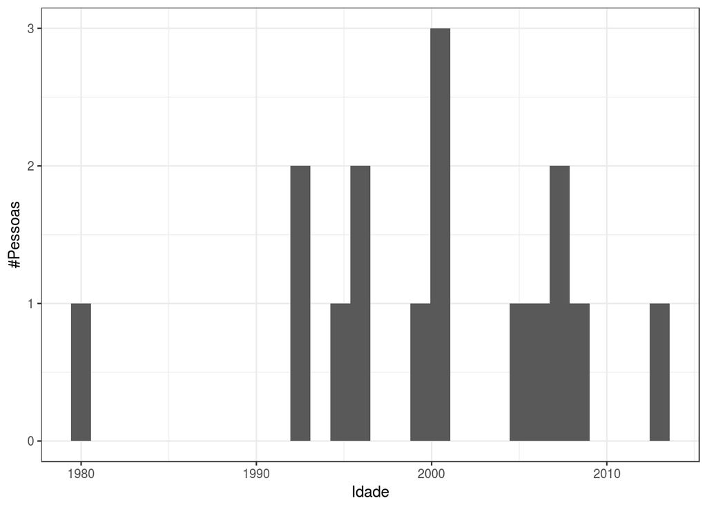

```r
personagens_informacoes %>%
  filter (age < 0 | age > 130) %>%
  ggplot(aes(x = age)) +
  geom_histogram() +
  ylab("#Pessoas") +
  xlab("Idade")
```

Percebemos que existem idades inconsistentes nos nossos dados, pessoas com idade superior a 1900 anos, logo, vamos remover os personagens que tem idade inferior a zero e superior a 130, a partir do código abaixo:

```r
personagens_informacoes = personagens_informacoes %>%
  filter(age >= 0 & age <= 130)
```

Agora, se observamos o histograma abaixo, percebemos que não existe pessoas com idades abaixo de zero e nem acima de 130.

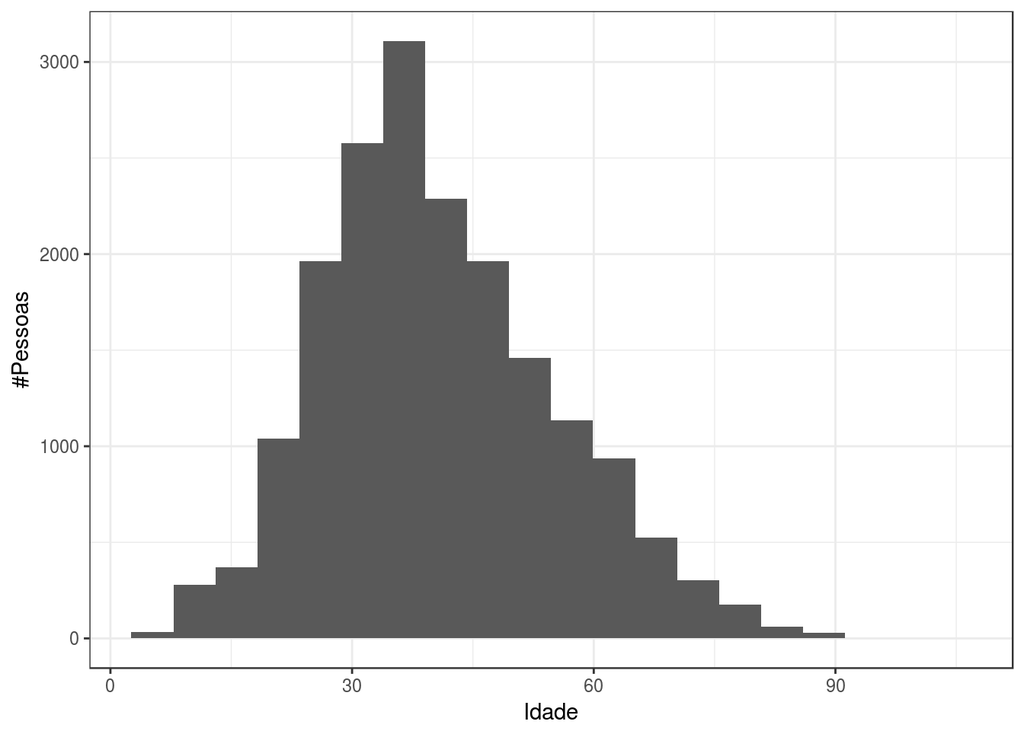

```r
personagens_informacoes %>%
  ggplot(aes(x = age)) +
  geom_histogram(bins = 20) +
  ylab("#Pessoas") +
  xlab("Idade")
```

O código abaixo separa as informações dos personagens homens dos mulheres, recuperando a quantidade de personagens do filme, mediana da idade e das quantidade de palavras, todas estas variáveis considerando por gênero, que serão os dados usados neste post. Em seguida, juntou-se as informações dos gêneros (número de personagens de cada gênero, idade e quantidade de palavras) e o título dos filmes, ou seja, no final vamos trabalhar com um conjunto com os seguintes dados:

- Quantidade de homens por filme;
- Quantidade de mulheres por filme;
- Mediana da quantidade das palavras ditas pelas mulheres em cada filma;
- Mediana da quantidade das palavras ditas pelos homens em cada filme;
- Mediana da idade das mulheres em cada filme;
- Mediana da idade dos homens em cada filme;

É importante falar que a mediana foi escolhida porque ela não sofre com valores extremos, o que acontece com a média.

```r
#junção das informações dos filmes com as dos personagens, a partir da variável em comum para ambos: 'script_id'
personagens_e_filmes= merge(filmes, personagens_informacoes, by="script_id")

# separação das informaões das mulheres
personagens_mulheres = personagens_e_filmes %>%
  filter(gender == "f") %>%
  group_by(script_id, imdb_id, title, year, gross) %>%
  #group_by(imdb_id, title) %>%
  summarize(qt_m=n(), p_m=median(words), i_m=median(age))

# separação das informaões dos homens
personagens_homens = personagens_e_filmes %>%
  filter(gender == "m") %>%
  group_by(script_id, imdb_id, title, year, gross) %>%
  #group_by(imdb_id, title) %>%
  summarize(qt_h=n(), p_h=median(words), i_h=median(age))

# junção das informações dos homens e mulheres
dados = merge(personagens_homens, personagens_mulheres, by=c('script_id','imdb_id','title','year','gross'))
#dados = merge(personagens_homens, personagens_mulheres, by=c('imdb_id','title'))

# remoção de variáveis que não serão usadas neste relatório
dados = dados %>%
  subset(select = -c(script_id,imdb_id,year,gross))
```

# Agrupando com Kmeans

A próxima etapa é agrupar os dados usando o Kmeans. A quantidade de grupos que foi escolhida para que o kmeans retornasse foi 4 (quatro).

```r
dw = dados
dw2 <- dw

dw2.scaled = dw2 %>%
  mutate_each(funs(as.vector(scale(.))), 2:7)
```

```
## `mutate_each()` is deprecated.
## Use `mutate_all()`, `mutate_at()` or `mutate_if()` instead.
## To map `funs` over a selection of variables, use `mutate_at()`
```

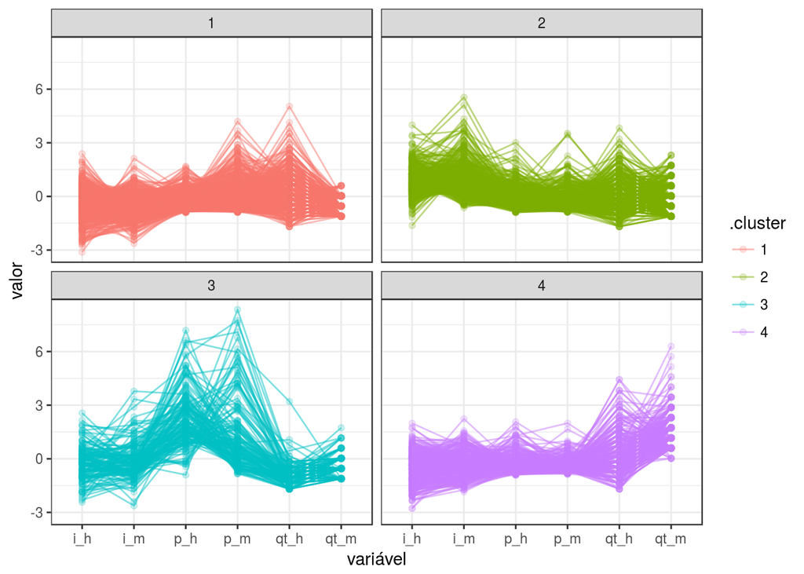

```r
# a linha a seguir é para que os grupos retornados pelo kmeans sejam determinísticos.
set.seed(123)

km = dw2.scaled %>%
    select(-title) %>%
    kmeans(centers = 4, nstart = 20)

dw2.scaled.km.long = km %>%
    augment(dw2.scaled) %>%
    gather(key = "variável",  value = "valor", -title, -.cluster)

dw2.scaled.km.long %>%
    ggplot(aes(x = `variável`, y = valor, group = title, colour = .cluster)) +
    geom_point(alpha = 0.2) +
    geom_line(alpha = .5) +
    facet_wrap(~ .cluster)
```

Em que, no gráfico acima:

- i_h: mediana das idades dos homens;
- i_m: mediana das idades das mulheres;
- gt_h: quantidade de homens;
- qt_m: quantidade de mulheres;
- p_h: mediana da quantidade das palavras ditas por homens; e
- p_m: mediana da quantidade das palavras ditas por mulheres.

# Redução de dimensionalidade - *Principal Component Analysis* (PCA)

A partir de agora, vamos usar a técnica PCA para reduzir a dimensionalidade dos nossos dados das 6 dimensões (de acordo com as 6 variáveis supracitadas) para 2 dimensões e observar os grupos numa visualização 2D..

O gráfico abaixo nos mostra como é a visualização em duas diumenões dos grupos 4 grupos obtidos a partir das 6 variáveis, mostrados acima. PC1 e PC2 correspondem as duas variáveis que reduzimos o nosso problema, ou seja, PC1 e PC2 têm informações sobre as 6 variáveis que tínhamos originalmente.

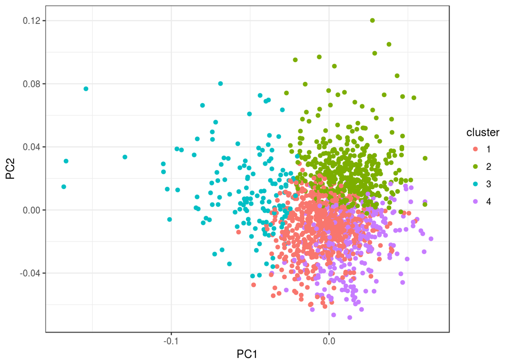

```r
autoplot(km, data = dw2.scaled, label = FALSE)
```

Para saber a representatividade de dos nossos PC’s da informação original obtida das 6 variáveis, basta observar no gráfico a seguir:

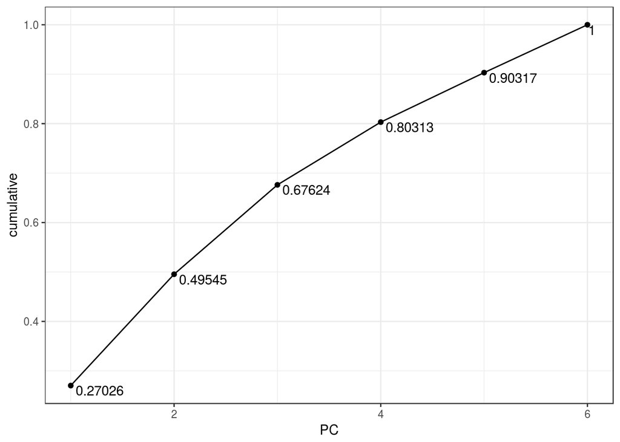

```r
filmes_pca = dw2.scaled %>%
    column_to_rownames("title") %>%
    prcomp(scale = FALSE)

tidy(filmes_pca, "pcs") %>%
    ggplot(aes(x = PC, y = cumulative, label = cumulative)) +
    geom_line() +
    geom_point() +
    geom_text(vjust = 1, hjust = -.1)
```

Onde, percebe-se que a redução do problema para duas dimensões (PC1 e PC2) resulta numa reprensatividade de 49,54% da informação que as 6 variáveis. Percebe-se também, a partir do gráfico acima, que na medida que aumentamos a quantidade de PC’s a representatividade aumenta. Entretanto, para este relatório, usaremos a redução para duas dimensões.

Como PC1 e PC2 são computadas a partir das nossas 6 variáveis iniciais, é importante saber a relação entre elas (PC1 e PC2 com nossas variáveis iniciais). O gráfico a seguir nos ajuda quanto a isso:

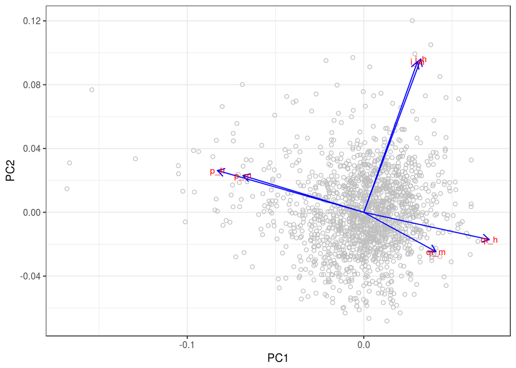

```r
autoplot(km, data = dw2.scaled, label = FALSE, label.size = 3, shape = T,
         colour = "grey",
         loadings = TRUE, loadings.colour = 'blue',
         loadings.label = TRUE,
         loadings.label.size = 3)
```

Percebe-se que **p_h**, **p_m**, **qt_h** e **qt_m** variam bastante quando um ponto está mais a esqueda ou a direita no gráfico (direção de PC1) é percebido também que elas têm um pouco de relação com PC2, pois se um ponto está mais acima ou abaixo no gráfico (direção de PC2) elas variam um pouco. Já **i_m** e **i_h** variam bastante quando um ponto está mais acima ou abaixo no gráfico enquanto variam pouco se um ponto está mais a direita ou a esqueda no gráfico. Então, concluimos que **p_h**, **p_m**, **qt_h** e **qt_m** têm muita relação com PC1 equanto **i_m** e **i_h** com PC2.

Outra forma de observar essa mesma informação é vendo PC1 e PC2 como duas funções das 6 variáveis originais:

```r
pr.out <- prcomp(select(dw2.scaled, -title), scale=FALSE)

tidy(pr.out,"variables") %>%
  filter(PC <= 2) %>%
  spread(column, value)
```

```
##   PC       i_h       i_m        p_h        p_m       qt_h       qt_m
## 1  1 0.2270599 0.2135619 -0.5827314 -0.4811783  0.4992089  0.2872581
## 2  2 0.6749510 0.6632433  0.1839837  0.1617658 -0.1202606 -0.1734030
```

Os valores da tabela são os coeficientes, e a leitura é que:  
- $PC1 = 0.227*i_h + 0.213*i_m - 0.582*p_h - 0.481*p_m + 0.499*qt_h + 0.287*qt_m $ e - $PC2 = 0.674*i_h + 0.663*i_m + 0.183*p_h + 0.161*p_m - 0.12*qt_h - 0.173*qt_m $

Percebe-se, a partir das funções acima, que $PC1$ é inversamente proporcional a **p_h** e **p_m**, ou seja, quando maior o valor dessas variáveis meor será o valor de $PC1$, equando as outras variáveis tem efeito contrário, quando mais elas aumentam maior será o valor de $PC1$.  
Já para a função de $PC2$, quanto maior for os valores de **qt_h** e **qt_m** menor será o valor de $PC2$, enquanto se aumentarmos os valores das outras variáveis aumentamos $PC2$.

Tudo isso que discutimos sobre as funções também é percebido no gráfico anterior.

# Correlação entre as variáveis e os PCs.

Podemos perceber também, a partir do gráfico anterior, que **p_h**, **p_m**, **qt_h** e **qt_m** têm uma correlação forte, assim como **i_h** e **i_m**. Sabendo disso, percebe-se que PC1 têm mais informação de **p_h**, **p_m**, **qt_h** e **qt_m** do que **i_h** e **i_m**, enquanto que para PC2 acontece o contrário, tendo mais informações de **i_h** e **i_m** do que das demais variáveis.  
Se duas ou mais variáveis têm uma correlação forte, significa que elas têm informação parecida e que se substituir essas variáveis que possuem correlação alta por apenas uma, perdendo pouca informação delas, que é o que acontece com PC1 e PC2.

# Grupos Encontrados…

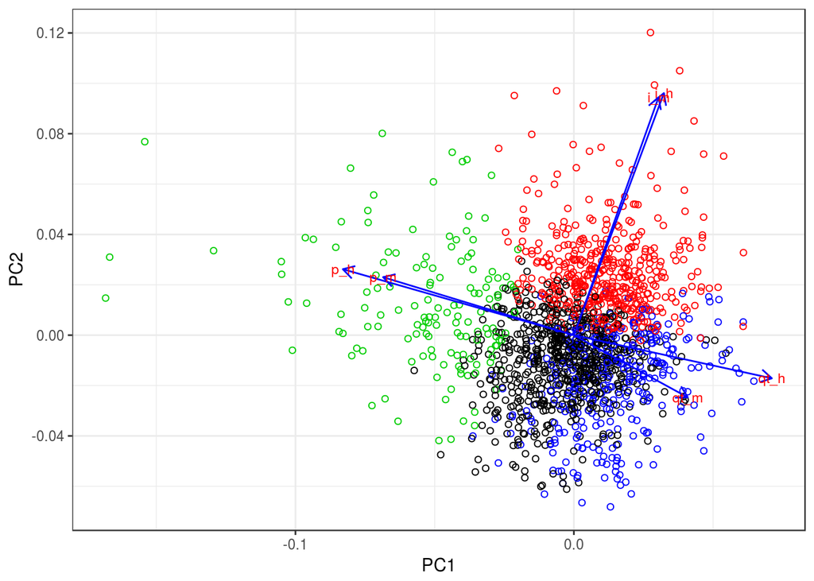

```r
autoplot(km, data = dw2.scaled, label = F, label.size = 3, shape = T,
         colour = km$cluster,
         loadings = TRUE, loadings.colour = 'blue',
         loadings.label = TRUE,
         loadings.label.size = 3)
```

Podemos perceber os seguintes grupos, a partir do gráfico acima:

*Experientes* (grupo com a cor vermelha), este é o grupo que parece ser o que tem os atores mais velhos, tanto homens quanto mulheres. Tem uma quantidade razoável de atores e nao falam muito nem pouco.  
*Falantes* (grupo com a cor verde), este é o gupo que tem os atores que mais falam nos filmes. Também aparenta ser um grupo bem equilibrado quanto a idade e o que tem menos atores.  
*Muito ator* (grupo com a cor azul), este é o grupo que tem a maior quantidade de atores (homens + mulheres) de todos. Também parece ser um grupo em que os atores têm pouca idade, no geral e é o que menos fala.  
*Meio Termo* (grupo com a cor preta), este grupo é o que tem menos idade, no geral, não falam muito durante o filme (mas também não é o que menos fala), não tem muitos atores (mas também não é o que tem menos). Parece ser um grupo que fica mais no meio termo.